# Using Models 2

Sonja

18/11/2021

## Using Models 2

#### Learning Objectives

- Review 1- and 2-sample t-tests
- Perform a 1-way Analysis of Variance (ANOVA)
- Perform a simple- and multiple- linear regressions
- Interpret model coefficient tables
- Interpret ANOVA table

##### Q1

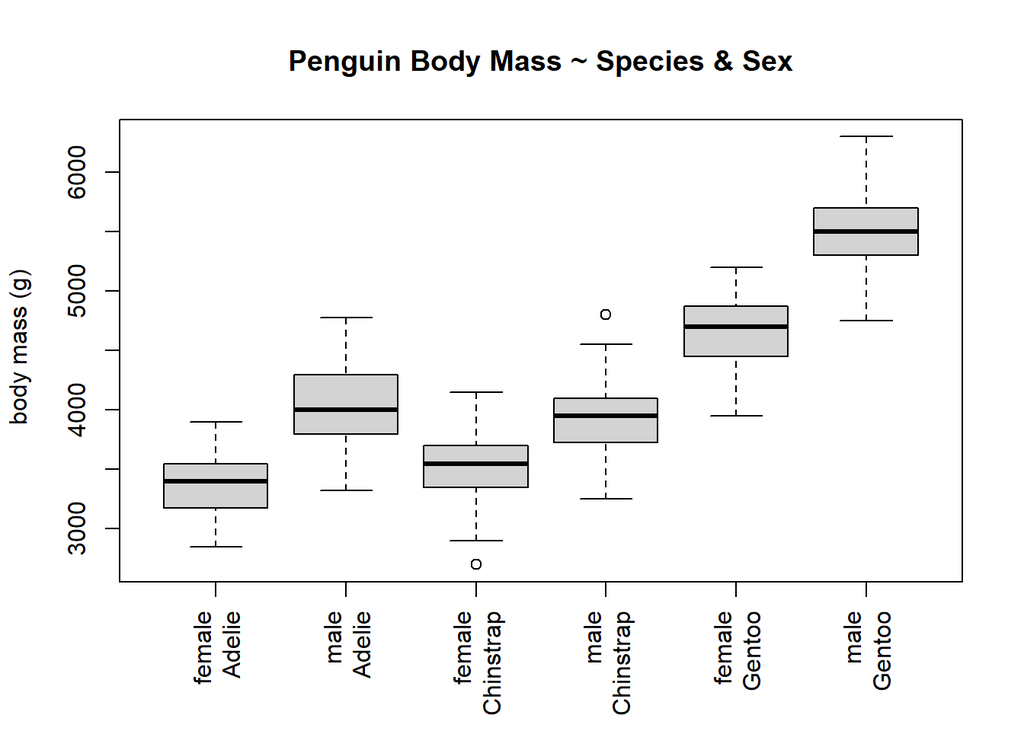

##### Q2

It appears that the body mass of the male penguins of Gentoo and Adelie are significantly different from that of the female penguins. This apparent difference is due to the clear separation of the median weight values and the second and third quartile ranges between Adelie and Gentoo male and female penguins.

##### Q3

I believe that adding sex to the model will greatly improve the model fit. If we look at the boxplots of both sexes of the Gentoo penguins we see that if they were combined the Gentoo penguin weight might not appear as significantly different from the other penguins because the female penguins weigh so much less than the male penguins.

##### Q4

```r
fit_both = lm(body_mass_g ~ sex*species, data = penguins)
summary(fit_both)
```

```
##
## Call:
## lm(formula = body_mass_g ~ sex * species, data = penguins)
##
## Residuals:
##     Min      1Q  Median      3Q     Max
## -827.21 -213.97   11.03  206.51  861.03
##
## Coefficients:
##                          Estimate Std. Error t value Pr(>|t|)
## (Intercept)               3368.84      36.21  93.030  < 2e-16 ***
## sexmale                    674.66      51.21  13.174  < 2e-16 ***
## speciesChinstrap           158.37      64.24   2.465  0.01420 *
## speciesGentoo             1310.91      54.42  24.088  < 2e-16 ***
## sexmale:speciesChinstrap  -262.89      90.85  -2.894  0.00406 **
## sexmale:speciesGentoo      130.44      76.44   1.706  0.08886 .
## ---
## Signif. codes:  0 '***' 0.001 '**' 0.01 '*' 0.05 '.' 0.1 ' ' 1
##
## Residual standard error: 309.4 on 327 degrees of freedom
##   (11 observations deleted due to missingness)
## Multiple R-squared:  0.8546, Adjusted R-squared:  0.8524
## F-statistic: 384.3 on 5 and 327 DF,  p-value: < 2.2e-16
```

##### Q5

The base case for the two-way model that includes sex and species is, sex = female, penguin = Adelie.

##### Q6

The names of the two coefficients needed to calculate the average mass of female Chinstrap penguins are “Intercept” and “speciesChinstrap”.

##### Q7

The predicted average mass of the female Chinstrap penguins is 3527.21 grams.

##### Q8

```r
dat_mass_means = aggregate(
  body_mass_g ~ species*sex,
  data = penguins,
  FUN = mean)
dat_mass_means
```

```
##     species    sex body_mass_g
## 1    Adelie female    3368.836
## 2 Chinstrap female    3527.206
## 3    Gentoo female    4679.741
## 4    Adelie   male    4043.493
## 5 Chinstrap   male    3938.971
## 6    Gentoo   male    5484.836
```

The observed mass of the female Chinstrap penguins is 3527.206 grams.